[GitHub](https://github.com/CDCgov/Rt-without-renewal)[](https://github.com/CDCgov/Rt-without-renewal/blob/main/docs/src/showcase/replications/chatzilena-2019/index.jl)

# Example: Statistical inference for ODE-based infectious disease models

# Introduction

## What are we going to do in this Vignette

In this vignette, we'll demonstrate how to use `EpiAware` in conjunction with [SciML ecosystem](https://sciml.ai/) for Bayesian inference of infectious disease dynamics. The model and data is heavily based on [Contemporary statistical inference for infectious disease models using Stan *Chatzilena et al. 2019*](https://www.sciencedirect.com/science/article/pii/S1755436519300325).

We'll cover the following key points:

1. Defining the deterministic ODE model from Chatzilena et al section 2.2.2 using SciML ODE functionality and an `EpiAware` observation model.
2. Build on this to define the stochastic ODE model from Chatzilena et al section 2.2.3 using an `EpiAware` observation model.
3. Fitting the deterministic ODE model to data from an Influenza outbreak in an English boarding school.
4. Fitting the stochastic ODE model to data from an Influenza outbreak in an English boarding school.

## What might I need to know before starting

This vignette builds on concepts from `EpiAware` observation models and a familarity with the `SciML` and `Turing` ecosystems would be useful but not essential.

## Packages used in this vignette

Alongside the `EpiAware` package we will use the `OrdinaryDiffEq` and `SciMLSensitivity` packages for interfacing with `SciML` ecosystem; this is a lower dependency usage of `DifferentialEquations.jl` that, respectively, exposes ODE solvers and adjoint methods for ODE solvees; that is the method of propagating parameter derivatives through functions containing ODE solutions. Bayesian inference will be done with `NUTS` from the `Turing` ecosystem. We will also use the `CairoMakie` package for plotting and `DataFramesMeta` for data manipulation.

```julia
using EpiAware
```

```julia
using Turing
```

```julia
using OrdinaryDiffEq, SciMLSensitivity #ODE solvers and adjoint methods
```

```julia
using Distributions, Statistics, LogExpFunctions #Statistics and special func packages
```

```julia
using CSV, DataFramesMeta #Data wrangling
```

```julia
using CairoMakie, PairPlots
```

```julia
using ReverseDiff #Automatic differentiation backend
```

```julia
begin #Date utility and set Random seed
    using Dates
    using Random
    Random.seed!(1234)
end
```

```
TaskLocalRNG()
```

# Single population SIR model

As mentioned in *Chatzilena et al* disease spread is frequently modelled in terms of ODE-based models. The study population is divided into compartments representing a specific stage of the epidemic status. In this case, susceptible, infected, and recovered individuals.

$$\begin{aligned} {dS \over dt} &= - \beta \frac{I(t)}{N} S(t) \\ {dI \over dt} &= \beta \frac{I(t)}{N} S(t) - \gamma I(t) \\ {dR \over dt} &= \gamma I(t). \\ \end{aligned}$$

where S(t) represents the number of susceptible, I(t) the number of infected and R(t) the number of recovered individuals at time t. The total population size is denoted by N (with N = S(t) + I(t) + R(t)), β denotes the transmission rate and γ denotes the recovery rate.

We can interface to the `SciML` ecosystem by writing a function with the signature:

> `(du, u, p, t) -> nothing`

Where:

- `du` is the *vector field* of the ODE problem, e.g. \({dS \over dt}\), \({dI \over dt}\) etc. This is calculated *in-place* (commonly denoted using ! in function names in Julia).
- `u` is the *state* of the ODE problem, e.g. \(S\), \(I\), etc.
- `p` is an object that represents the parameters of the ODE problem, e.g. \(\beta\), \(\gamma\).
- `t` is the time of the ODE problem.

We do this for the SIR model described above in a function called `sir!`:

```julia
function sir!(du, u, p, t)
    S, I, R = u
    β, γ = p
    du[1] = -β * I * S
    du[2] = β * I * S - γ * I
    du[3] = γ * I

    return nothing
end
```

```
sir! (generic function with 1 method)
```

We combine vector field function `sir!` with a initial condition `u0` and the integration period `tspan` to make an `ODEProblem`. We do not define the parameters, these will be defined within an inference approach.

```julia
sir_prob = ODEProblem(
    sir!,
    N .* [0.99, 0.01, 0.0],
    (0.0, (Date(1978, 2, 4) - Date(1978, 1, 22)).value + 1)
)
```

[output not shown]

Note that this is analogous to the `EpiProblem` approach we expose from `EpiAware`, as used in the [Mishra et al replication](https://cdcgov.github.io/Rt-without-renewal/dev/showcase/replications/mishra-2020/). The difference is that here we are going to use ODE solvers from the `SciML` ecosystem to generate the dynamics of the underlying infections. In the linked example, we use latent process generation exposed by `EpiAware` as the underlying generative process for underlying dynamics.

## Data for inference

There was a brief, but intense, outbreak of Influenza within the (semi-) closed community of a boarding school reported to the British medical journal in 1978. The outbreak lasted from 22nd January to 4th February and it is reported that one infected child started the epidemic and then it spread rapidly. Of the 763 children at the boarding scholl, 512 became ill.

We downloaded the data of this outbreak using the R package `outbreaks` which is maintained as part of the R Epidemics Consortium(RECON).

```julia
data = "https://raw.githubusercontent.com/CDCgov/Rt-without-renewal/refs/heads/main/EpiAware/docs/src/showcase/replications/chatzilena-2019/influenza_england_1978_school.csv2" |>
       url -> CSV.read(download(url), DataFrame) |>
              df -> @transform(df,
    :ts=(:date .- minimum(:date)) .|> d -> d.value + 1.0,)
```

|  | Column1 | date | in_bed | convalescent | ts |
| --- | --- | --- | --- | --- | --- |
| 1 | 1 | 1978-01-22 | 3 | 0 | 1.0 |
| 2 | 2 | 1978-01-23 | 8 | 0 | 2.0 |
| 3 | 3 | 1978-01-24 | 26 | 0 | 3.0 |
| 4 | 4 | 1978-01-25 | 76 | 0 | 4.0 |
| 5 | 5 | 1978-01-26 | 225 | 9 | 5.0 |
| 6 | 6 | 1978-01-27 | 298 | 17 | 6.0 |
| 7 | 7 | 1978-01-28 | 258 | 105 | 7.0 |
| 8 | 8 | 1978-01-29 | 233 | 162 | 8.0 |
| 9 | 9 | 1978-01-30 | 189 | 176 | 9.0 |
| 10 | 10 | 1978-01-31 | 128 | 166 | 10.0 |
| 11 | 11 | 1978-02-01 | 68 | 150 | 11.0 |
| 12 | 12 | 1978-02-02 | 29 | 85 | 12.0 |
| 13 | 13 | 1978-02-03 | 14 | 47 | 13.0 |
| 14 | 14 | 1978-02-04 | 4 | 20 | 14.0 |

```julia
N = 763;
```

## Inference for the deterministic SIR model

The boarding school data gives the number of children "in bed" and "convalescent" on each of 14 days from 22nd Jan to 4th Feb 1978. We follow *Chatzilena et al* and treat the number "in bed" as a proxy for the number of children in the infectious (I) compartment in the ODE model.

The full observation model is:

**NB: Chatzilena et al give \(\lambda_t = \int_0^t \beta \frac{I(s)}{N} S(s) - \gamma I(s)ds = I(t) - I(0).\) However, this doesn't match their underlying stan code.**

From `EpiAware`, we have the `PoissonError` struct which defines the probabilistic structure of this observation error model.

```julia
obs = PoissonError()
```

```
PoissonError()
```

Now we can write the probabilistic model using the `Turing` PPL. Note that instead of using \(I(t)\) directly we do the [softplus](https://en.wikipedia.org/wiki/Softplus) transform on \(I(t)\) implemented by `LogExpFunctions.log1pexp`. The reason is that the solver can return small negative numbers, the soft plus transform smoothly maintains positivity which being very close to \(I(t)\) when \(I(t) > 2\).

```julia
@model function deterministic_ode_mdl(y_t, ts, obs, prob, N;
        solver = AutoTsit5(Rosenbrock23())
)
    ##Priors##
    β ~ LogNormal(0.0, 1.0)
    γ ~ Gamma(0.004, 1 / 0.002)
    S₀ ~ Beta(0.5, 0.5)

    ##remake ODE model##
    _prob = remake(prob;
        u0 = [S₀, 1 - S₀, 0.0],
        p = [β, γ]
    )

    ##Solve remade ODE model##

    sol = solve(_prob, solver;
        saveat = ts,
        verbose = false)

    ##log-like accumulation using obs##
    λt = log1pexp.(N * sol[2, :]) # #expected It
    @submodel generated_y_t = generate_observations(obs, y_t, λt)

    ##Generated quantities##
    return (; sol, generated_y_t, R0 = β / γ)
end
```

```
deterministic_ode_mdl (generic function with 2 methods)
```

We instantiate the model in two ways:

1. `deterministic_mdl`: This conditions the generative model on the data observation. We can sample from this model to find the posterior distribution of the parameters.
2. `deterministic_uncond_mdl`: This *doesn't* condition on the data. This is useful for prior and posterior predictive modelling.

Here we construct the `Turing` model directly, in the [Mishra et al replication](https://cdcgov.github.io/Rt-without-renewal/dev/showcase/replications/mishra-2020/) we using the `EpiProblem` functionality to build a `Turing` model under the hood. Because in this note we are using a mix of functionality from `SciML` and `EpiAware`, we construct the model to sample from directly.

```julia
deterministic_mdl = deterministic_ode_mdl(data.in_bed, data.ts, obs, sir_prob, N);
```

```julia
deterministic_uncond_mdl = deterministic_ode_mdl(
    fill(missing, length(data.in_bed)), data.ts, obs, sir_prob, N);
```

We add a useful plotting utility.

```julia
function plot_predYt(data, gens; title::String, ylabel::String)
    fig = Figure()
    ga = fig[1, 1:2] = GridLayout()

    ax = Axis(ga[1, 1];
        title = title,
        xticks = (data.ts[1:3:end], data.date[1:3:end] .|> string),
        ylabel = ylabel
    )
    pred_Yt = mapreduce(hcat, gens) do gen
        gen.generated_y_t
    end |> X -> mapreduce(vcat, eachrow(X)) do row
        quantile(row, [0.5, 0.025, 0.975, 0.1, 0.9, 0.25, 0.75])'
    end

    lines!(ax, data.ts, pred_Yt[:, 1]; linewidth = 3, color = :green, label = "Median")
    band!(
        ax, data.ts, pred_Yt[:, 2], pred_Yt[:, 3], color = (:green, 0.2), label = "95% CI")
    band!(
        ax, data.ts, pred_Yt[:, 4], pred_Yt[:, 5], color = (:green, 0.4), label = "80% CI")
    band!(
        ax, data.ts, pred_Yt[:, 6], pred_Yt[:, 7], color = (:green, 0.6), label = "50% CI")
    scatter!(ax, data.in_bed, label = "data")
    leg = Legend(ga[1, 2], ax; framevisible = false)
    hidespines!(ax)

    fig
end
```

```
plot_predYt (generic function with 1 method)
```

**Prior predictive sampling**

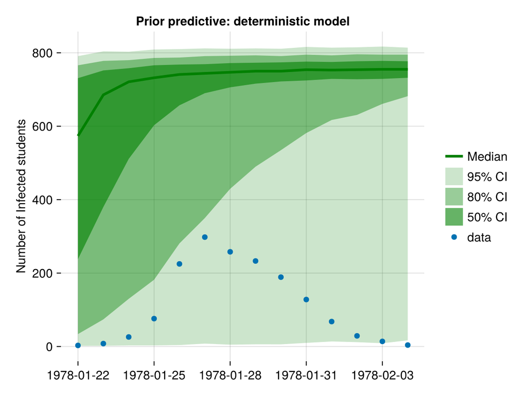

```julia
let
    prior_chn = sample(deterministic_uncond_mdl, Prior(), 2000)
    gens = generated_quantities(deterministic_uncond_mdl, prior_chn)
    plot_predYt(data, gens;
        title = "Prior predictive: deterministic model",
        ylabel = "Number of Infected students"
    )
end
```

The prior predictive checking suggests that *a priori* our parameter beliefs are very far from the data. Approaching the inference naively can lead to poor fits.

1. We choose a switching ODE solver which switches between explicit (`Tsit5`) and implicit (`Rosenbrock23`) solvers. This helps avoid the ODE solver failing when the sampler tries extreme parameter values. This is the default `solver = AutoTsit5(Rosenbrock23())` above.
2. We locate the maximum likelihood point, that is we ignore the influence of the priors, as a useful starting point for `NUTS`.

```julia
nmle_tries = 100
```

```
100
```

```julia
mle_fit = map(1:nmle_tries) do _
    fit = try
        maximum_likelihood(deterministic_mdl)
    catch
        (lp = -Inf,)
    end
end |>
          fits -> (findmax(fit -> fit.lp, fits)[2], fits) |>
                  max_and_fits -> max_and_fits[2][max_and_fits[1]]
```

```
ModeResult with maximized lp of -67.36
[1.8991528341063986, 0.4808836287337563, 0.9995360155493609]
```

```julia
mle_fit.optim_result.retcode
```

```
ReturnCode.Success = 1
```

Note that we choose the best out of 100 tries for the MLE estimators.

Now, we sample aiming at 1000 samples for each of 4 chains.

```julia
chn = sample(
    deterministic_mdl, NUTS(), MCMCThreads(), 1000, 4;
    initial_params = fill(mle_fit.values.array, 4)
)
```

|  | iteration | chain | β | γ | S₀ | lp | n_steps | is_accept | ... |
| --- | --- | --- | --- | --- | --- | --- | --- | --- | --- |
| 1 | 501 | 1 | 1.89926 | 0.506816 | 0.99948 | -82.0424 | 7.0 | 1.0 |  |
| 2 | 502 | 1 | 1.83012 | 0.475987 | 0.999415 | -80.2447 | 15.0 | 1.0 |  |
| 3 | 503 | 1 | 1.83113 | 0.480837 | 0.999362 | -79.6098 | 15.0 | 1.0 |  |
| 4 | 504 | 1 | 1.94375 | 0.493731 | 0.999609 | -80.0092 | 15.0 | 1.0 |  |
| 5 | 505 | 1 | 1.97912 | 0.493033 | 0.999666 | -80.6603 | 7.0 | 1.0 |  |
| 6 | 506 | 1 | 1.92652 | 0.484617 | 0.99963 | -80.2942 | 15.0 | 1.0 |  |
| 7 | 507 | 1 | 1.95664 | 0.481118 | 0.999635 | -79.6873 | 9.0 | 1.0 |  |
| 8 | 508 | 1 | 1.96588 | 0.482278 | 0.999654 | -79.8495 | 7.0 | 1.0 |  |
| 9 | 509 | 1 | 1.871 | 0.474391 | 0.999552 | -81.5075 | 15.0 | 1.0 |  |
| 10 | 510 | 1 | 1.88225 | 0.476209 | 0.999524 | -79.3149 | 7.0 | 1.0 |  |
| ... |  |  |  |  |  |  |  |  |  |

```julia
describe(chn)
```

```
2-element Vector{ChainDataFrame}:
 Summary Statistics (3 x 8)
 Quantiles (3 x 6)
```

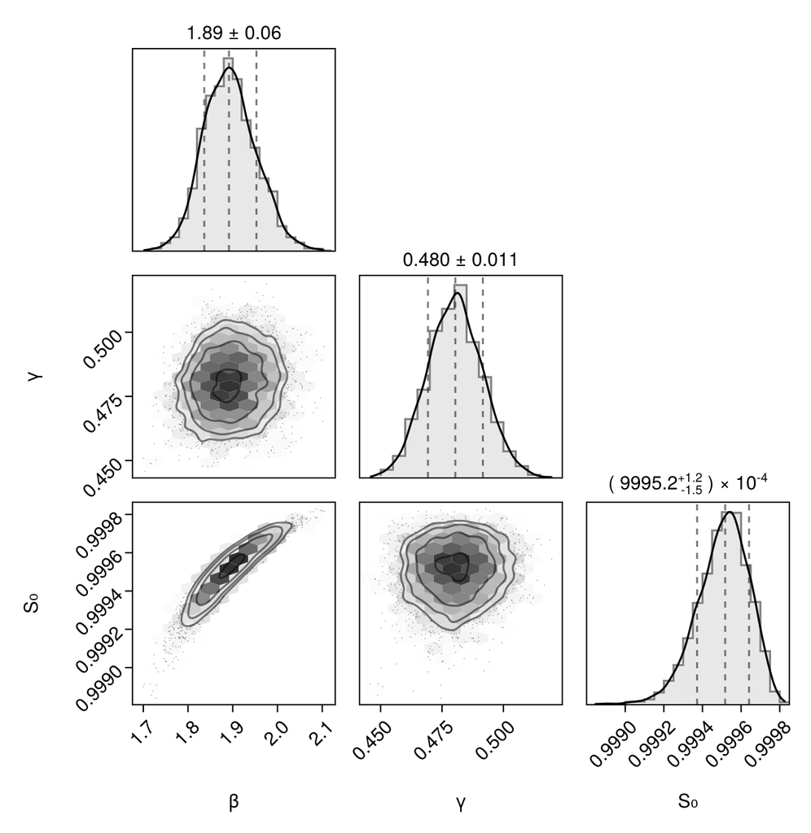

```julia
pairplot(chn)
```

**Posterior predictive plotting**

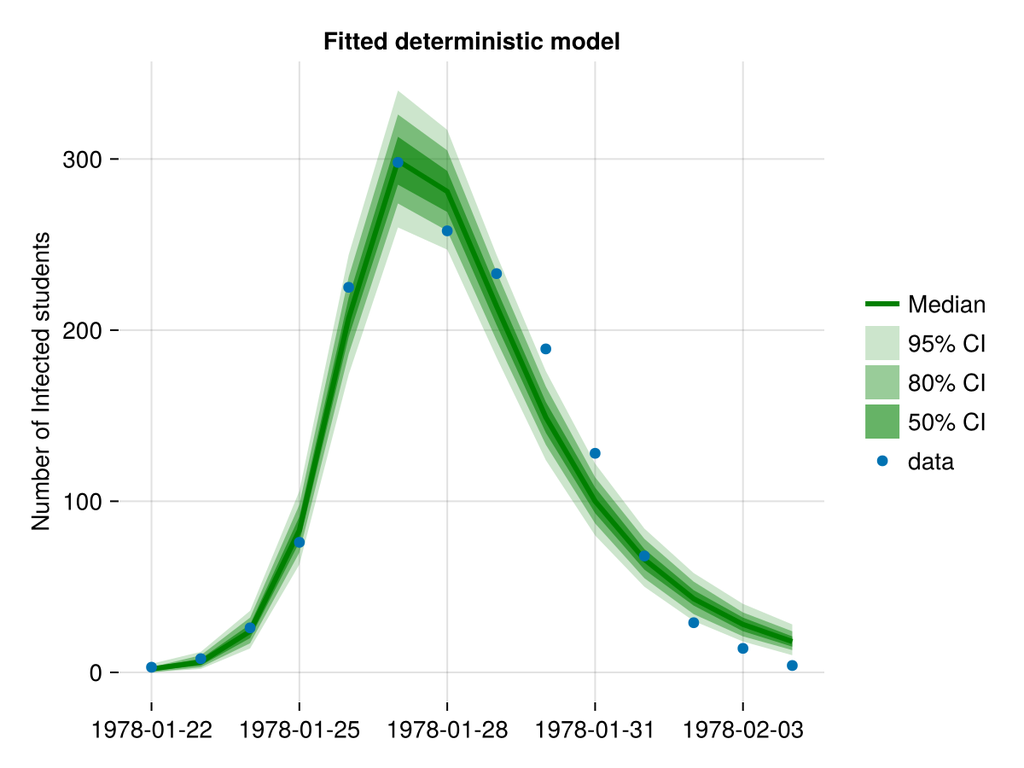

```julia
let
    gens = generated_quantities(deterministic_uncond_mdl, chn)
    plot_predYt(data, gens;
        title = "Fitted deterministic model",
        ylabel = "Number of Infected students"
    )
end
```

## Inference for the Stochastic SIR model

In *Chatzilena et al*, they present an auto-regressive model for connecting the outcome of the ODE model to illness observations. The argument is that the stochastic component of the model can absorb the noise generated by a possible mis-specification of the model.

In their approach they consider \(\kappa_t = \log \lambda_t\) where \(\kappa_t\) evolves according to an Ornstein-Uhlenbeck process:

$$d\kappa_t = \phi(\mu_t - \kappa_t) dt + \sigma dB_t.$$

Which has transition density:

$$\kappa_{t+1} | \kappa_t \sim N\Big(\mu_t + \left(\kappa_t - \mu_t\right)e^{-\phi}, {\sigma^2 \over 2 \phi} \left(1 - e^{-2\phi} \right)\Big).$$

Where \(\mu_t = \log(I(t))\).

We modify this approach since it implies that the \(\mu_t\) is treated as constant between observation times.

Instead we redefine \(\kappa_t\) as the log-residual:

$$\kappa_t = \log(\lambda_t / I(t)).$$

With the transition density:

$$\kappa_{t+1} | \kappa_t \sim N\Big(\kappa_te^{-\phi}, {\sigma^2 \over 2 \phi} \left(1 - e^{-2\phi} \right)\Big).$$

This is an AR(1) process.

The stochastic model is completed:

We will using the `AR` struct from `EpiAware` to define the auto-regressive process in this model which has a direct parameterisation of the `AR` model.

To convert from the formulation above we sample from the priors, and define `HalfNormal` priors based on the sampled prior means of \(e^{-\phi}\) and \({\sigma^2 \over 2 \phi} \left(1 - e^{-2\phi} \right)\). We also add a strong prior that \(\kappa_1 \approx 0\).

```julia
ϕs = rand(truncated(Normal(0, 100), lower = 0.0), 1000)
```

```
1000-element Vector{Float64}:
  83.6143998036499
  59.84521404902012
  56.40017890849385
 281.42865170346164
  20.91890715982588
  36.202994127083
  71.03163753413315
   ⋮
 232.7501733978284
 101.82812547247973
  85.81742706397105
   8.112395517639671
  55.47764585625805
 146.7727411432326
```

```julia
σ²s = rand(InverseGamma(0.1, 0.1), 1000) .|> x -> 1 / x
```

```
1000-element Vector{Float64}:
 0.0950562811111961
 3.0352038045468e-5
 0.4690770415026051
 0.0411576967896433
 3.9437545070372675
 0.2057582192305372
 8.480739367481015e-5
 ⋮
 2.227497348166806e-5
 0.0026008517630239825
 0.004801814136269194
 0.08400466181906113
 1.3948248672661614
 2.293385810228216
```

```julia
sampled_AR_damps = ϕs .|> ϕ -> exp(-ϕ)
```

```
1000-element Vector{Float64}:
 4.861021675570432e-37
 1.0222421170133606e-26
 3.20415503618323e-25
 5.9853495090441484e-123
 8.223071245415233e-10
 1.8933871364906192e-16
 1.4169410369855538e-31
 ⋮
 8.27721109649392e-102
 5.978703343451708e-45
 5.369884875317924e-38
 0.00029979983650594514
 8.060547389907895e-25
 1.8088744633255173e-64
```

```julia
sampled_AR_stds = map(ϕs, σ²s) do ϕ, σ²
    (1 - exp(-2 * ϕ)) * σ² / (2 * ϕ)
end
```

```
1000-element Vector{Float64}:
 0.0005684205192790653
 2.535878476481527e-7
 0.004158471219246099
 7.312279069760588e-5
 0.09426291911202529
 0.0028417293126124627
 5.969691578210995e-7
 ⋮
 4.785167967113508e-8
 1.277079270072046e-5
 2.7976917396333543e-5
 0.005177549226123559
 0.012571053130842436
 0.007812710290632735
```

We define the AR(1) process by matching means of `HalfNormal` prior distributions for the damp parameters and std deviation parameter to the calculated the prior means from the *Chatzilena et al* definition.

```julia
ar = AR(
    damp_priors = [HalfNormal(mean(sampled_AR_damps))],
    init_priors = [Normal(0, 0.001)],
    ϵ_t = HierarchicalNormal(std_prior = HalfNormal(mean(sampled_AR_stds)))
)
```

```
AR{Product{Continuous, HalfNormal{Float64}, FillArrays.Fill{HalfNormal{Float64}, 1, Tuple{Base.OneTo{Int64}}}}, DistributionsAD.TuringScalMvNormal{Vector{Float64}, Float64}, Int64, HierarchicalNormal{Float64, HalfNormal{Float64}, Bool}}(Distributions.Product{Distributions.Continuous, HalfNormal{Float64}, FillArrays.Fill{HalfNormal{Float64}, 1, Tuple{Base.OneTo{Int64}}}}(v=Fill(HalfNormal{Float64}(μ=0.003953158673208398), 1)), DistributionsAD.TuringScalMvNormal{Vector{Float64}, Float64}(m=[0.0], σ=0.001), 1, HierarchicalNormal{Float64, HalfNormal{Float64}, Bool}(0.0, HalfNormal{Float64}(μ=0.019814191412215125), false))
```

We can sample directly from the behaviour specified by the `ar` struct to do prior predictive checking on the `AR(1)` process.

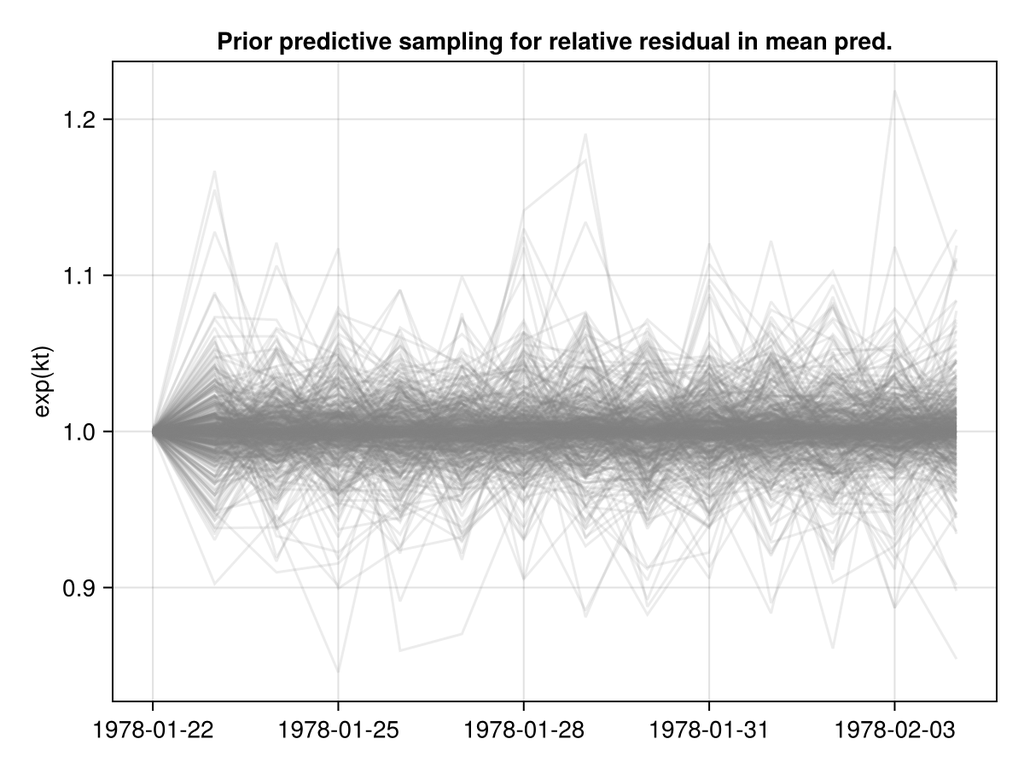

```julia
let
    nobs = size(data, 1)
    ar_mdl = generate_latent(ar, nobs)
    fig = Figure()
    ax = Axis(fig[1, 1],
        xticks = (data.ts[1:3:end], data.date[1:3:end] .|> string),
        ylabel = "exp(kt)",
        title = "Prior predictive sampling for relative residual in mean pred."
    )
    for i in 1:500
        lines!(ax, ar_mdl() .|> exp, color = (:grey, 0.15))
    end
    fig
end
```

We see that the choice of priors implies an *a priori* belief that the extra observation noise on the mean prediction of the ODE model is fairly small, approximately 10% relative to the mean prediction.

We can now define the probabilistic model. The stochastic model assumes a (random) time-varying ascertainment, which we implement using the `Ascertainment` struct from `EpiAware`. Note that instead of implementing an ascertainment factor `exp.(κₜ)` directly, which can be unstable for large primal values, by default `Ascertainment` uses the `LogExpFunctions.xexpy` function which implements \(x\exp(y)\) stabily for a wide range of values.

To distinguish random variables sampled by various sub-processes `EpiAware` process types create prefixes. The default for `Ascertainment` is just the string `"Ascertainment"`, but in this case we use the less verbose `"va"` for "varying ascertainment".

```julia
mdl_prefix = "va"
```

```
"va"
```

Now we can construct our time varying ascertianment model. The main keyword arguments here are `model` and `latent_model`. `model` sets the connection between the expected observation and the actual observation. In this case, we reuse our `PoissonError` model from above. `latent_model` sets the modification model on the expected values. In this case, we use the `AR` process we defined above.

```julia
varying_ascertainment = Ascertainment(
    model = obs,
    latent_model = ar,
    latent_prefix = mdl_prefix
)
```

```
Ascertainment{PoissonError, AbstractTuringLatentModel, EpiAware.EpiObsModels.var"#Ascertainment##6#Ascertainment##7", String}(PoissonError(), PrefixLatentModel{AR{Product{Continuous, HalfNormal{Float64}, FillArrays.Fill{HalfNormal{Float64}, 1, Tuple{Base.OneTo{Int64}}}}, DistributionsAD.TuringScalMvNormal{Vector{Float64}, Float64}, Int64, HierarchicalNormal{Float64, HalfNormal{Float64}, Bool}}, String}(AR{Product{Continuous, HalfNormal{Float64}, FillArrays.Fill{HalfNormal{Float64}, 1, Tuple{Base.OneTo{Int64}}}}, DistributionsAD.TuringScalMvNormal{Vector{Float64}, Float64}, Int64, HierarchicalNormal{Float64, HalfNormal{Float64}, Bool}}(Distributions.Product{Distributions.Continuous, HalfNormal{Float64}, FillArrays.Fill{HalfNormal{Float64}, 1, Tuple{Base.OneTo{Int64}}}}(v=Fill(HalfNormal{Float64}(μ=0.003953158673208398), 1)), DistributionsAD.TuringScalMvNormal{Vector{Float64}, Float64}(m=[0.0], σ=0.001), 1, HierarchicalNormal{Float64, HalfNormal{Float64}, Bool}(0.0, HalfNormal{Float64}(μ=0.019814191412215125), false)), "va"), EpiAware.EpiObsModels.var"#Ascertainment##6#Ascertainment##7"(), "va")
```

Now we can declare the full model in the `Turing` PPL.

```julia
@model function stochastic_ode_mdl(y_t, ts, obs, prob, N;
        solver = AutoTsit5(Rosenbrock23())
)

    ##Priors##
    β ~ LogNormal(0.0, 1.0)
    γ ~ Gamma(0.004, 1 / 0.002)
    S₀ ~ Beta(0.5, 0.5)

    ##Remake ODE model##
    _prob = remake(prob;
        u0 = [S₀, 1 - S₀, 0.0],
        p = [β, γ]
    )

    ##Solve ODE model##
    sol = solve(_prob, solver;
        saveat = ts,
        verbose = false
    )
    λt = log1pexp.(N * sol[2, :])

    ##Observation##
    @submodel generated_y_t = generate_observations(obs, y_t, λt)

    ##Generated quantities##
    return (; sol, generated_y_t, R0 = β / γ)
end
```

```
stochastic_ode_mdl (generic function with 2 methods)
```

```julia
stochastic_mdl = stochastic_ode_mdl(
    data.in_bed,
    data.ts,
    varying_ascertainment,
    sir_prob,
    N
)
```

[output not shown]

```julia
stochastic_uncond_mdl = stochastic_ode_mdl(
    fill(missing, length(data.in_bed)),
    data.ts,
    varying_ascertainment,
    sir_prob,
    N
)
```

[output not shown]

**Prior predictive checking**

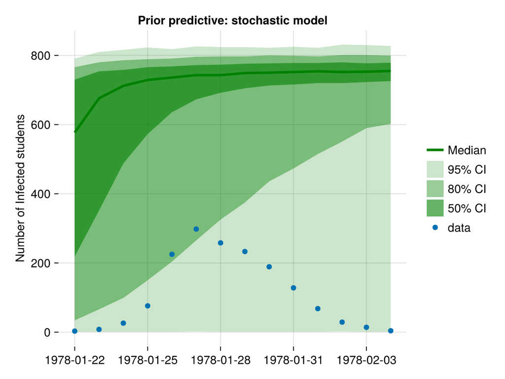

```julia
let
    prior_chn = sample(stochastic_uncond_mdl, Prior(), 2000)
    gens = generated_quantities(stochastic_uncond_mdl, prior_chn)
    plot_predYt(data, gens;
        title = "Prior predictive: stochastic model",
        ylabel = "Number of Infected students"
    )
end
```

The prior predictive checking again shows misaligned prior beliefs; for example *a priori* without data we would not expect the median prediction of number of ill children as about 600 out of 763 after 1 day.

The latent process for the log-residuals \(\kappa_t\) doesn't make much sense without priors, so we look for a reasonable MAP point to start NUTS from. We do this by first making an initial guess which is a mixture of:

1. The posterior averages from the deterministic model.
2. The prior averages of the structure parameters of the AR(1) process.
3. Zero for the time-varying noise underlying the AR(1) process.

```julia
rand(stochastic_mdl)
```

```
(β = 0.7359638879103444, γ = 1.4566878879879976e-190, S₀ = 0.12735366620768637, var"va.ar_init" = [-0.0011508500509483032], var"va.damp_AR" = [0.005148999059260376], var"va.std" = 0.011752739772646202, var"va.ϵ_t" = [1.3563517884243796, 0.0536512099617657, 0.5287038007120217, -0.4748182976148183, -1.153272004836023, 0.09478686416298424, 1.998604964722539, -0.14366993746996362, 0.5446525177273797, 1.305128668255458, 0.7414247158341648, -0.20188843425089453, -0.015578352849654243])
```

```julia
initial_guess = [[mean(chn[:β]),
                     mean(chn[:γ]),
                     mean(chn[:S₀]),
                     mean(ar.init_prior)[1],
                     mean(ar.damp_prior)[1],
                     mean(ar.ϵ_t.std_prior)
                 ]
                 zeros(13)]
```

```
19-element Vector{Float64}:
 1.8940223105245442
 0.4803599545749335
 0.9995052527555247
 0.0
 0.003953158673208398
 0.019814191412215125
 0.0
 ⋮
 0.0
 0.0
 0.0
 0.0
 0.0
 0.0
```

Starting from the initial guess, the MAP point is calculated rapidly in one pass.

```julia
map_fit_stoch_mdl = maximum_a_posteriori(stochastic_mdl;
    adtype = AutoReverseDiff(),
    initial_params = initial_guess
)
```

```
ModeResult with maximized lp of -68.83
[1.9180272960283704, 0.4917063596593232, 0.9995544889694196, 1.37017388714095e-6, 0.00012404938004259154, 0.0750193741262563, 0.15821472805783715, 0.18461039774180799, -0.31506183013889477, 0.6443372930587868, 0.014744696255513357, -0.5505672760751753, 0.8305802562467982, 1.7985067299709847, 1.5270244489668514, 0.29125964602513915, -0.7114513073116149, -0.7956237463308781, -0.8767414006017348]
```

Now we can run NUTS, sampling 1000 posterior draws per chain for 4 chains.

```julia
chn2 = sample(
    stochastic_mdl,
    NUTS(; adtype = AutoReverseDiff(true)),
    MCMCThreads(), 1000, 4;
    initial_params = fill(map_fit_stoch_mdl.values.array, 4)
)
```

|  | iteration | chain | β | γ | S₀ | va.ar_init[1] | va.damp_AR[1] | va.std | ... |
| --- | --- | --- | --- | --- | --- | --- | --- | --- | --- |
| 1 | 501 | 1 | 1.95904 | 0.477827 | 0.999648 | 0.000340994 | 0.00332025 | 0.0307952 |  |
| 2 | 502 | 1 | 1.98213 | 0.47396 | 0.999692 | -0.000365772 | 0.00635716 | 0.101366 |  |
| 3 | 503 | 1 | 1.83503 | 0.479551 | 0.999357 | 0.000316402 | 0.00304702 | 0.0345708 |  |
| 4 | 504 | 1 | 1.80509 | 0.48476 | 0.999196 | -0.00109977 | 0.00430712 | 0.0530347 |  |
| 5 | 505 | 1 | 1.78474 | 0.504153 | 0.999294 | 0.000267126 | 0.000584894 | 0.0467464 |  |
| 6 | 506 | 1 | 1.88507 | 0.509433 | 0.999477 | 0.000373208 | 0.000507519 | 0.0499409 |  |
| 7 | 507 | 1 | 1.87413 | 0.513107 | 0.999511 | 0.000802146 | 0.000581229 | 0.0818056 |  |
| 8 | 508 | 1 | 1.98085 | 0.501294 | 0.999645 | 0.000666905 | 0.00236329 | 0.0784388 |  |
| 9 | 509 | 1 | 1.95505 | 0.510736 | 0.999627 | 0.000181538 | 0.00194692 | 0.0609507 |  |
| 10 | 510 | 1 | 1.99361 | 0.492806 | 0.999676 | 0.000323381 | 0.00766252 | 0.06478 |  |
| ... |  |  |  |  |  |  |  |  |  |

```julia
describe(chn2)
```

```
2-element Vector{ChainDataFrame}:
 Summary Statistics (19 x 8)
 Quantiles (19 x 6)
```

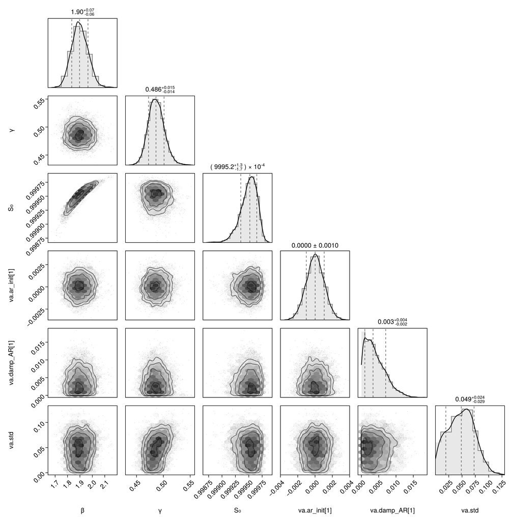

```julia
pairplot(chn2[[:β, :γ, :S₀, Symbol(mdl_prefix * ".std"),
    Symbol(mdl_prefix * ".ar_init[1]"), Symbol(mdl_prefix * ".damp_AR[1]")]])
```

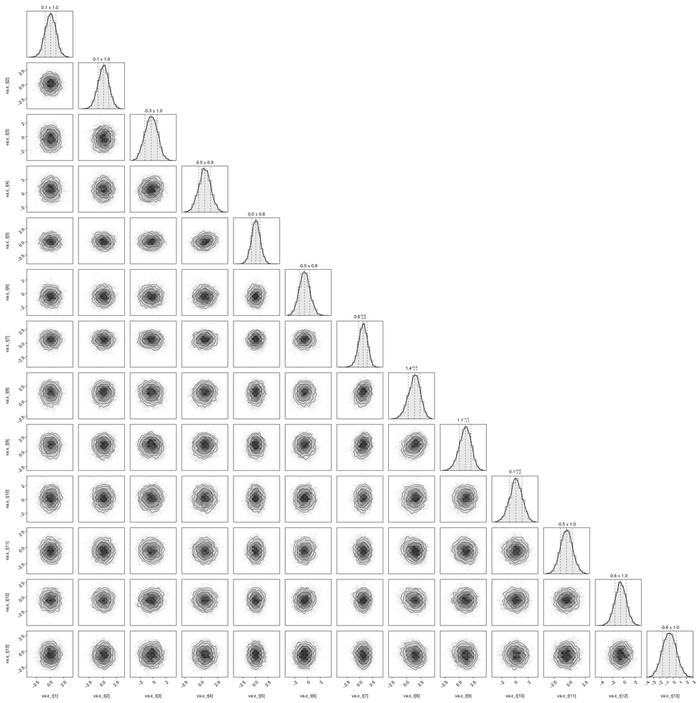

```julia
let
    vars = mapreduce(vcat, 1:13) do i
        Symbol(mdl_prefix * ".ϵ_t[$i]")
    end
    pairplot(chn2[vars])
end
```

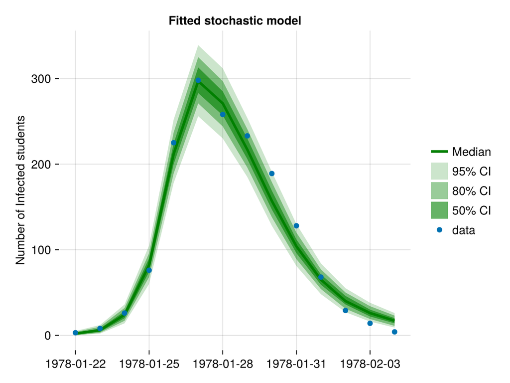

```julia
let
    gens = generated_quantities(stochastic_uncond_mdl, chn2)
    plot_predYt(data, gens;
        title = "Fitted stochastic model",
        ylabel = "Number of Infected students"
    )
end
```